# Complex Sampling Design

Kursus R: Pengenalan & Praktikal (NCD)

Authors

Dr. Mohd Azmi Bin Suliman

Pusat Penyelidikan Penyakit Tak Berjangkit, IKU

Published

Tuesday, 23 January 2024

# 1 Introduction

## 1.1 Complex Sampling Design

- **Census vs. Sampling**
  - Sampling is more feasible than a census, which attempts to reach everyone.
  - Sampling is less costly and time-consuming.
- **Random Sampling Limitations**
  - Purely random sampling may not adequately represent all groups, particularly minorities.
- **Stratified Sampling**
  - Stratification ensures that important subgroups within the population are adequately represented.
- **Cluster Sampling**
  - Clustering (e.g., by district or Enumeration Block) can increase efficiency, especially in geographically dispersed populations.
- **Adjustments in Complex Sampling**
  - Stratification and clustering alter initial selection probabilities.
  - Weight adjustments are necessary to equalize these probabilities.
- **Post-stratification**
  - Helps in aligning the sample estimates with the broader state or national populations.
- **NHMS Sampling Methodology**
  - Employs a two-stage stratified random sampling.
  - First stage: stratification by state.
  - Second stage: stratification by urban/rural locality.
  - Primary sampling unit: Enumeration Block; Secondary: Living Quarters.
- **Accounting for Design Effect**
  - Sample size needs to be inflated to accommodate the increased variance due to the complex design.

## 1.2 Disclaimer

1. Limited exposure on complex sampling design
2. Mainly on verbal explanation and short reading
3. No formal training, and a lot of reverse engineering

# 2 Practical

## 2.1 Setup your Project

1. Open your RStudio
2. Create Project
- File -> New Project…
- New Directory -> New Project
  - set Directory Name, e.g., `Sesi 4 NHMS`
  - ensure the project directory is in default working directory, i.e., `~/Documents/RStudio`
  - click `Create Project` button
3. Copy your NHMS dataset into the working directory
- `Files` pane -> click the `⚙️ More 🔻` button -> select `Show Folder in New Window`
- Copy your NHMS dataset into the working directory
- alternatively, you can also check you working directory, and copy the working directory into your File Explorer

```r
getwd() %>%
  clipr::write_clip()
```

## 2.2 Create Quarto Document

1. Create Quarto Document
- `File` -> `New File` -> `Quarto Document...`
2. Setup the new Quarto document
- set title, e.g., `Sesi 4 - NHMS`
- untick `use visual markdown editor`
- click `Create Empty Document`
3. Update the YAML metadata to make the document self-contained

```r
---
title: "Sesi 4 - NHMS"
format:
  html:
    embed-resources: true

---
```

# 3 Analysis

## 3.1 Dataset Context

- Every analysis should have context
- In this practical session, these are the context
  - this practical is based on NHMS 2019 NCD dataset
  - we will focus on hypercholesterolaemia module of NHMS 2019
  - we will focus on known hypercholesterolaemia status - the column `known_chol` as the outcome

## 3.2 Import Dataset

SPSS sav file.

- Import the spss’s sav file
  - On the `Files` pane, click on the spss .sav file
- Select `Import Dataset...`
- Copy the code into r code chunk
- add function `as_factor(_)`
  - Note: as_factor (from `haven` package),
  - **NOT** as.factor (from `base` package)

````markdown
```{r}
library(tidyverse)
library(haven)

nhms19ds <- read_sav("nhms19ds.sav") %>%
  as_factor()

nhms19ds %>%
  select(-c(indvid, hh_id)) %>%
  slice_sample(n = 30)
```
````

| state | strata_gp | A2101 | A2104 | A2104_grp | A2106_5grp | A2107 | A2108_3grp | A2109_4grp | A2221 | A2222_7grp | A2222_5grp | state_st | ebid | wtfinal_ncd | c01 | c02 | c03 | c03a | c04a | c04b | c04c | c04d | c05 | c06 | u303 | known_chol | undiagnosed_chol | total_chol | bodyweight1 | … |
| --- | --- | --- | --- | --- | --- | --- | --- | --- | --- | --- | --- | --- | --- | --- | --- | --- | --- | --- | --- | --- | --- | --- | --- | --- | --- | --- | --- | --- | --- | --- |
| Terengganu | Rural | Male | 43 | 40-44 | Malay | Malaysian Citizen | SIngle | Primary education | Self-employed | Self employed | Self employed | 22 | 11020030076 | 661.55397 | No | No | NA | NA | NA | NA | NA | NA | NA | NA | 3.9 | No | No | No | 62.3 | … |
| Kelantan | Urban | Male | 58 | 55-59 | Malay | Malaysian Citizen | Married | Secondary education | Self-employed | Self employed | Self employed | 5 | 03020050057 | 1590.91100 | Yes | Yes | 1 year and more | 7 | Yes | Yes | No | No | No | Government hospital | 5.1 | Yes | No | Yes | 68.4 | … |
| WP Putrajaya | Urban | Female | 36 | 35-39 | Malay | Malaysian Citizen | Married | Tertiary education | Private employee | Private employee | Private employee | 30 | 16010010066 | 118.18696 | No | No | NA | NA | NA | NA | NA | NA | NA | NA | 4.7 | No | No | No | 70.1 | … |
| Perak | Urban | Female | 84 | 75 & above | Chinese | Malaysian Citizen | Widow(er)/Divercee | No formal education | NA | Not working (unemployed, health problem, old age & child) | NA | 15 | 08010460025 | 4039.89376 | Yes | Yes | NA | NA | Yes | Yes | Yes | Yes | Yes | NA | 2.8 | Yes | No | Yes | 65.4 | … |
| Kelantan | Urban | Female | 78 | 75 & above | Malay | Malaysian Citizen | Widow(er)/Divercee | No formal education | NA | Not working (unemployed, health problem, old age & child) | NA | 5 | 03020050057 | 930.02131 | No | No | NA | NA | NA | NA | NA | NA | NA | NA | 7.6 | No | Yes | Yes | 56.5 | … |
| Perlis | Urban | Female | 58 | 55-59 | Malay | Malaysian Citizen | Married | Secondary education | NA | Unpaid worker / Homemaker / Caregiver | Unpaid worker / Homemaker / Caregiver | 17 | 09010040014 | 239.99523 | Yes | Yes | 1 year and more | 6 | Yes | Yes | Yes | Yes | No | Government hospital | 5.1 | Yes | No | Yes | 64.8 | … |
| Sarawak | Rural | Female | 29 | 25-29 | Other Bumiputeras | Malaysian Citizen | Married | Primary education | NA | Unpaid worker / Homemaker / Caregiver | Unpaid worker / Homemaker / Caregiver | 26 | 13210520006 | 3039.95941 | No | No | NA | NA | NA | NA | NA | NA | NA | NA | 2.6 | No | No | No | 83.7 | … |
| Pahang | Rural | Female | 61 | 60-64 | Malay | Malaysian Citizen | Widow(er)/Divercee | Primary education | NA | Unpaid worker / Homemaker / Caregiver | Unpaid worker / Homemaker / Caregiver | 12 | 06080190049 | 1016.67888 | Yes | No | NA | NA | NA | NA | NA | NA | NA | NA | 5.3 | No | Yes | Yes | 57.7 | … |
| WP Kl | Urban | Male | 42 | 40-44 | Chinese | Malaysian Citizen | Married | Secondary education | Self-employed | Self employed | Self employed | 27 | 14010190083 | 2754.59276 | No | No | NA | NA | NA | NA | NA | NA | NA | NA | 5.7 | No | Yes | Yes | 73.7 | … |
| Terengganu | Rural | Male | 35 | 35-39 | Malay | Malaysian Citizen | Married | Secondary education | Self-employed | Self employed | Self employed | 22 | 11040060058 | 726.67209 | Yes | No | NA | NA | NA | NA | NA | NA | NA | NA | 3 | No | No | No | 48.6 | … |

[output cut: 20 more lines]

- dont forget to briefly look at your data

```r
skimr::skim(nhms19ds)
```

- since that we have missing data, especially at our intended outcome variable, filtering missing data will reduce our headache later.

````markdown
```{r}
nhms19ds <- read_sav("nhms19ds.sav") %>%
  as_factor() %>%
  filter(!is.na(known_chol))
```
````

- R and survey package can analyse the outcome variable `known_chol` eventhough it is categorical variable
- the variable can also be numerical variable, but need to be in binary 0 and 1 form
- for this practical session, we will convert to numerical and use the numerical variable

````markdown
```{r}
nhms19ds <- read_sav("nhms19ds.sav") %>%
  as_factor() %>%
  filter(!is.na(known_chol)) %>%
  mutate(known_cholN = as.numeric(known_chol)-2)
```
````

## 3.3 Specifiying the Design

- In Complex Sampling Design, specifying the design is the first step.
  - This is similar with CSPlan in SPSS
- Required information include

| Required Information/Specification | Common NHMS Variable Name |
| --- | --- |
| Cluster IDs | EB ID |
| Strata | State.Strata, State.wt |
| Sampling Weight | ADW, weight_final, weight |

````markdown
```{r}
nhms19ds %>%
  select(-c(indvid, hh_id)) %>%
  slice_sample(n = 30)
```
````

| state | strata_gp | A2101 | A2104 | A2104_grp | A2106_5grp | A2107 | A2108_3grp | A2109_4grp | A2221 | A2222_7grp | A2222_5grp | state_st | ebid | wtfinal_ncd | c01 | c02 | c03 | c03a | c04a | c04b | c04c | c04d | c05 | c06 | u303 | known_chol | undiagnosed_chol | total_chol | bodyweight1 | … |
| --- | --- | --- | --- | --- | --- | --- | --- | --- | --- | --- | --- | --- | --- | --- | --- | --- | --- | --- | --- | --- | --- | --- | --- | --- | --- | --- | --- | --- | --- | --- |
| Kelantan | Rural | Female | 33 | 30-34 | Malay | Malaysian Citizen | Widow(er)/Divercee | Secondary education | Self-employed | Self employed | Self employed | 6 | 03070120104 | 1723.10056 | No | NA | NA | NA | NA | NA | NA | NA | NA | NA | 3.9 | No | No | No | 63.7 | … |
| Perak | Urban | Female | 53 | 50-54 | Chinese | Malaysian Citizen | Married | Secondary education | NA | Not working (unemployed, health problem, old age & child) | NA | 15 | 08030480076 | 7067.03225 | Yes | No | NA | NA | NA | NA | NA | NA | NA | NA | NA | No | No | No | 70 | … |
| WP Labuan | Urban | Male | 63 | 60-64 | Others | Malaysian Citizen | Married | No formal education | NA | Retiree | Retiree | 28 | 15010020020 | 100.25884 | Yes | Yes | 1 year and more | 10 | Yes | Yes | Yes | Yes | Yes | Government clinic | 4.3 | Yes | No | Yes | 54.4 | … |
| Selangor | Urban | Male | 23 | 20-24 | Indian | Malaysian Citizen | SIngle | Primary education | Private employee | Private employee | Private employee | 19 | 10020570043 | 6900.11118 | No | No | NA | NA | NA | NA | NA | NA | NA | NA | 3.1 | No | No | No | 75 | … |
| Kelantan | Urban | Male | 66 | 65-69 | Malay | Malaysian Citizen | Married | Primary education | Self-employed | Self employed | Self employed | 5 | 03020050057 | 1000.02300 | No | No | NA | NA | NA | NA | NA | NA | NA | NA | 4.1 | No | No | No | 71 | … |
| Sabah | Rural | Female | 25 | 25-29 | Other Bumiputeras | Malaysian Citizen | Married | Primary education | NA | Unpaid worker / Homemaker / Caregiver | Unpaid worker / Homemaker / Caregiver | 24 | 12230300010 | 2620.00438 | No | NA | NA | NA | NA | NA | NA | NA | NA | NA | 3.4 | No | No | No | 74.8 | … |
| Pahang | Rural | Male | 50 | 50-54 | Malay | Malaysian Citizen | Married | Primary education | Self-employed | Not working (unemployed, health problem, old age & child) | NA | 12 | 06040300055 | 681.23840 | Yes | Yes | 1 year and more | 6 | Yes | No | Yes | Yes | No | Government clinic | 6.2 | Yes | No | Yes | 76.3 | … |
| Kedah | Rural | Female | 59 | 55-59 | Malay | Malaysian Citizen | Married | Secondary education | Self-employed | Self employed | Self employed | 4 | 02090190083 | 1023.06238 | Yes | Yes | 1 year and more | 12 | Yes | Yes | Yes | Yes | Yes | Government clinic | 6.8 | Yes | No | Yes | 52.5 | … |
| Sabah | Urban | Male | 39 | 35-39 | Others | Non-Malaysian Citizen | Married | Primary education | Private employee | Private employee | Private employee | 23 | 12020510034 | 3330.00556 | No | No | NA | NA | NA | NA | NA | NA | NA | NA | 2.7 | No | No | No | 62.8 | … |
| Melaka | Rural | Male | 21 | 20-24 | Malay | Malaysian Citizen | SIngle | Secondary education | Private employee | Private employee | Private employee | 8 | 04010140015 | 179.99768 | No | No | NA | NA | NA | NA | NA | NA | NA | NA | 3.6 | No | No | No | 79 | … |

[output cut: 20 more lines]

````markdown
```{r}
nhms19ds %>%
  select(-c(indvid, hh_id)) %>%
  slice_sample(n = 30) %>%
  select(ebid, state_st, state, strata_gp, wtfinal_ncd)
```
````

| ebid | state_st | state | strata_gp | wtfinal_ncd |
| --- | --- | --- | --- | --- |
| 15010020015 | 28 | WP Labuan | Urban | 99.84283 |
| 14010180045 | 27 | WP Kl | Urban | 1400.06572 |
| 12010020437 | 23 | Sabah | Urban | 12120.02026 |
| 11050090045 | 21 | Terengganu | Urban | 2099.97900 |
| 07020030042 | 13 | P. Pinang | Urban | 4271.27445 |
| 10071340067 | 20 | Selangor | Rural | 1171.42096 |
| 10071340022 | 20 | Selangor | Rural | 4100.06606 |
| 16010019066 | 30 | WP Putrajaya | Urban | 86.49700 |
| 08090670018 | 16 | Perak | Rural | 1080.01373 |
| 13010050017 | 26 | Sarawak | Rural | 2150.07206 |

[output cut: 20 more lines]

- In R, Complex Sampling Design Analysis was done with package `survey::`
  - `srvyr::` package bring parts of tidyverse syntax to survey analysis, using the `survey::` package
  - defining the design should be done in the first step
  - formula form is used in defining the design: **~** symbol
  - in addition, since our ebid is nested within strata, we need to add `nest` parameter
- this is the unweighted design

````markdown
```{r}
library(survey)

nhms_unwdsg <- svydesign(id = ~1,
                         weights = ~1,
                         data = nhms19ds)
```
````

- and this is the weighted design

````markdown
```{r}
library(survey)

nhms_surdsg <- svydesign(id = ~ebid,
                         strata = ~state_st,
                         weights = ~wtfinal_ncd,
                         data = nhms19ds,
                         nest = T)
```
````

- we may also want to add option if there is lonely PSU
  - i.e., single ebid in state.strata

````markdown
```{r}
options(survey.lonely.psu = 'adjust',
        survey.adjust.domain.lonely = TRUE)
```
````

- we can use function `summary(_)` to view our design

````markdown
```{r}
summary(nhms_unwdsg)
```
````

```
Independent Sampling design (with replacement)
svydesign(id = ~1, weights = ~1, data = nhms19ds)
Probabilities:
   Min. 1st Qu.  Median    Mean 3rd Qu.    Max.
      1       1       1       1       1       1
Data variables:
 [1] "state"            "strata_gp"        "A2101"            "A2104"
 [5] "A2104_grp"        "A2106_5grp"       "A2107"            "A2108_3grp"
 [9] "A2109_4grp"       "A2221"            "A2222_7grp"       "A2222_5grp"
[13] "indvid"           "hh_id"            "state_st"         "ebid"
[17] "wtfinal_ncd"      "c01"              "c02"              "c03"
[21] "c03a"             "c04a"             "c04b"             "c04c"
[25] "c04d"             "c05"              "c06"              "u303"
[29] "known_chol"       "undiagnosed_chol" "total_chol"       "bodyweight1"
[33] "bodyweight2"      "bodyheight1"      "bodyheight2"      "wc2"
[37] "wc1"              "weight"           "height"           "wc"
[41] "known_cholN"
```

````markdown
```{r}
summary(nhms_surdsg)
```
````

```
Stratified 1 - level Cluster Sampling design (with replacement)
With (475) clusters.
svydesign(id = ~ebid, strata = ~state_st, weights = ~wtfinal_ncd,
    data = nhms19ds, nest = T)
Probabilities:
     Min.   1st Qu.    Median      Mean   3rd Qu.      Max.
1.405e-05 3.608e-04 7.000e-04 2.850e-03 2.000e-03 1.200e-01
Stratum Sizes:
             1   2   3   4   5   6   7   8   9  10  11  12  13  14  15  16  17
obs        584 274 281 263 281 307 331 319 294 245 302 338 307 333 317 265 258
design.PSU  27  13  13  11  12  12  12  12  12  12  12  12  14  12  16  11  12
actual.PSU  27  13  13  11  12  12  12  12  12  12  12  12  14  12  16  11  12
            18  19  20  21  22  23  24  25  26  27  28 29  30
obs        294 898 224 301 341 405 429 388 358 504 420 99 506
design.PSU  12  53  11  11  13  20  19  16  14  25  19  4  33
actual.PSU  12  53  11  11  13  20  19  16  14  25  19  4  33
Data variables:
 [1] "state"            "strata_gp"        "A2101"            "A2104"
 [5] "A2104_grp"        "A2106_5grp"       "A2107"            "A2108_3grp"
 [9] "A2109_4grp"       "A2221"            "A2222_7grp"       "A2222_5grp"
[13] "indvid"           "hh_id"            "state_st"         "ebid"
[17] "wtfinal_ncd"      "c01"              "c02"              "c03"
[21] "c03a"             "c04a"             "c04b"             "c04c"
[25] "c04d"             "c05"              "c06"              "u303"
[29] "known_chol"       "undiagnosed_chol" "total_chol"       "bodyweight1"
[33] "bodyweight2"      "bodyheight1"      "bodyheight2"      "wc2"
[37] "wc1"              "weight"           "height"           "wc"
[41] "known_cholN"
```

## 3.4 Estimating Known Hypercholesterolaemia

variable `known_cholN`

### 3.4.1 Calculating Unweighted Count

- to calculate count (both unweigted and estimated population), `svytotal(_)` function from `survey::` package is used
  - for unweighted count, use unweighted design

```r
?svytotal
```

````markdown
```{r}
svytotal(x = ~known_cholN,
         design = nhms_unwdsg,
         na.rm = T)
```
````

```
            total     SE
known_cholN  2015 40.339
```

````markdown
```{r}
svytotal(x = ~known_chol,
         design = nhms_unwdsg,
         na.rm = T)
```
````

```
              total     SE
known_cholN/A     0  0.000
known_cholNo   8451 40.339
known_cholYes  2015 40.339
```

### 3.4.2 Calculating Estimated Population

- similar to unweighted count, for estimated population, we will use `svytotal(_)` function from `survey::` package
  - use weighted design

````markdown
```{r}
svytotal(x = ~known_cholN,
         design = nhms_surdsg,
         na.rm = T)
```
````

```
              total     SE
known_cholN 2868124 103013
```

````markdown
```{r}
svytotal(x = ~known_chol,
         design = nhms_surdsg,
         na.rm = T)
```
````

```
                 total     SE
known_cholN/A        0      0
known_cholNo  18410557 416696
known_cholYes  2868124 103013
```

### 3.4.3 Calculating the Prevalence

- calculating prevalence using `svymean(_)` function from `survey::` package
  - variable can be coded as 0/1 or in factor form
  - check help page for further info

```r
?svymean
```

- in the help page, simplest `svymean(_)` function require
  - the variable that we want to calculate the prevalence (i.e. the variable `known_cholN`)
  - survey design (i.e. the `nhms_surdsg` object that contain the survey design)

````markdown
```{r}
svymean(x = ~known_cholN,
        design = nhms_surdsg)
```
````

```
               mean     SE
known_cholN 0.13479 0.0051
```

````markdown
```{r}
svymean(x = ~known_chol,
        design = nhms_surdsg)
```
````

```
                 mean     SE
known_cholN/A 0.00000 0.0000
known_cholNo  0.86521 0.0051
known_cholYes 0.13479 0.0051
```

### 3.4.4 Calculating the Confindence Interval

- generally, to extract the CI info, we can use `confint(_)` function, however special parameter have to specified because of how the CI is estimated
  - default `confint(_)` function use “mean” method, in which Wald-type interval calculated on the probability scale

````markdown
```{r}
svymean(x = ~known_cholN,
        design = nhms_surdsg) %>%
  confint()
```
````

```
                2.5 %    97.5 %
known_cholN 0.1248631 0.1447141
```

- to change the CI estimate method, use `svyciprop(_)` from `survey::` package

```r
?svyciprop
```

- there was several method, but default method in R is “logit” method
- if we want to mimic SPSS and SUDAAN, use “xlogit” method

````markdown
```{r}
svyciprop(formula = ~known_cholN,
          design = nhms_surdsg) %>%
  attr(., "ci")
```
````

```
     2.5%     97.5%
0.1251425 0.1450549
```

````markdown
```{r}
svyciprop(formula = ~known_cholN,
          design = nhms_surdsg,
          method = "lo") %>%
  attr(., "ci")
```
````

```
     2.5%     97.5%
0.1251425 0.1450549
```

````markdown
```{r}
svyciprop(formula = ~known_cholN,
          design = nhms_surdsg,
          method = "xl") %>%
  attr(., "ci")
```
````

```
     2.5%     97.5%
0.1251425 0.1450549
```

## 3.5 Subpopulation by State

- For subpopulation analysis, we use `svyby(_)` function, and specified the subset variable

```r
?svyby
```

### 3.5.1 Unweighted count

````markdown
```{r}
svyby(formula = ~known_cholN,
      by = ~state,
      design = nhms_unwdsg,
      FUN = svytotal,
      na.rm.all = T)
```
````

|  | state | known_cholN | se |
| --- | --- | --- | --- |
| Johor | Johor | 142 | 11.835826 |
| Kedah | Kedah | 117 | 10.756538 |
| Kelantan | Kelantan | 93 | 9.601168 |
| Melaka | Melaka | 139 | 11.711833 |
| N. Sembilan | N. Sembilan | 136 | 11.586440 |
| Pahang | Pahang | 85 | 9.182468 |
| P. Pinang | P. Pinang | 134 | 11.502043 |
| Perak | Perak | 150 | 12.159947 |
| Perlis | Perlis | 144 | 11.917730 |
| Selangor | Selangor | 203 | 14.109628 |

[output cut: 6 more lines]

### 3.5.2 Estimated Population

````markdown
```{r}
svyby(formula = ~known_cholN,
      by = ~state,
      design = nhms_surdsg,
      FUN = svytotal,
      na.rm.all = T)
```
````

|  | state | known_cholN | se |
| --- | --- | --- | --- |
| Johor | Johor | 258211.549 | 25858.242 |
| Kedah | Kedah | 215999.510 | 26719.081 |
| Kelantan | Kelantan | 119011.604 | 12354.893 |
| Melaka | Melaka | 91977.114 | 9169.257 |
| N. Sembilan | N. Sembilan | 132201.325 | 17467.092 |
| Pahang | Pahang | 114423.991 | 15172.104 |
| P. Pinang | P. Pinang | 231596.480 | 34596.410 |
| Perak | Perak | 312700.928 | 41500.990 |
| Perlis | Perlis | 28231.665 | 2443.229 |
| Selangor | Selangor | 549486.158 | 56486.320 |

[output cut: 6 more lines]

### 3.5.3 Prevalence

````markdown
```{r}
svyby(formula = ~known_cholN,
      by = ~state,
      design = nhms_surdsg,
      FUN = svymean,
      na.rm.all = T)
```
````

|  | state | known_cholN | se |
| --- | --- | --- | --- |
| Johor | Johor | 0.1063011 | 0.011230290 |
| Kedah | Kedah | 0.1680896 | 0.021351496 |
| Kelantan | Kelantan | 0.1062219 | 0.007317001 |
| Melaka | Melaka | 0.1541648 | 0.018935842 |
| N. Sembilan | N. Sembilan | 0.1875535 | 0.029291093 |
| Pahang | Pahang | 0.1123269 | 0.013826582 |
| P. Pinang | P. Pinang | 0.1845757 | 0.027017257 |
| Perak | Perak | 0.2022228 | 0.024764654 |
| Perlis | Perlis | 0.1765938 | 0.019038936 |
| Selangor | Selangor | 0.1199109 | 0.013727667 |

[output cut: 6 more lines]

### 3.5.4 CI for Prevalence

- unfortunately, `svyciprop(_)` can’t be use with `svyby(_)` function
  - need to subset manually
    - but when subset, the df is affected, thus need to specified using the overall design
    - add parameter `df = degf(design)`

````markdown
```{r}
nhms_surdsg_johor <- subset(nhms_surdsg,
                            state == "Johor")

svyciprop(formula = ~known_cholN,
          design = nhms_surdsg_johor,
          method = "xl",
          df = degf(nhms_surdsg)) %>%
  attr(., "ci")
```
````

```
      2.5%      97.5%
0.08616262 0.13047453
```

- alternatively, we can either create custom function, or use loop

````markdown
```{r}
svyciprop_by <- function(x, design, by) {
  by_var <- deparse(substitute(by))

  by_levels <- unique(design$variables[[by_var]])

  calculate_ci <- function(stratum) {
    subset_design <- subset(design, design$variables[[by_var]] == stratum)
    result <- svyciprop(x, design = subset_design, method = "xl", df = degf(design))
    return(attr(result, "ci"))
  }

  ci_results <- purrr::map(by_levels, calculate_ci)

  tibble::tibble(subset = by_levels, ci = ci_results) %>%
    tidyr::unnest_wider(ci, names_sep = "_") %>%
    dplyr::rename("Lower 95% CI" = "ci_2.5%",
                  "Upper 95% CI" = "ci_97.5%")
}

svyciprop_by(x = ~known_cholN, design = nhms_surdsg, by = state)
```
````

| subset | Lower 95% CI | Upper 95% CI |
| --- | --- | --- |
| Johor | 0.08616262 | 0.1304745 |
| Kedah | 0.13018651 | 0.2143091 |
| Kelantan | 0.09267557 | 0.1214831 |
| Melaka | 0.12050078 | 0.1951466 |
| N. Sembilan | 0.13660576 | 0.2519575 |
| Pahang | 0.08788660 | 0.1425019 |
| P. Pinang | 0.13723625 | 0.2436335 |
| Perak | 0.15787266 | 0.2552556 |
| Perlis | 0.14222594 | 0.2171638 |
| Selangor | 0.09544252 | 0.1496147 |

[output cut: 6 more lines]

## 3.6 Logistic Regression

````markdown
```{r}
svyglm(known_chol ~ strata_gp, nhms_surdsg, family = quasibinomial) %>%
  summary()
```
````

```
Call:
svyglm(formula = known_chol ~ strata_gp, design = nhms_surdsg,
    family = quasibinomial)

Survey design:
svydesign(id = ~ebid, strata = ~state_st, weights = ~wtfinal_ncd,
    data = nhms19ds, nest = T)

Coefficients:
               Estimate Std. Error t value Pr(>|t|)
(Intercept)    -1.83690    0.05134 -35.779   <2e-16 ***
strata_gpRural -0.10511    0.08976  -1.171    0.242
---
Signif. codes:  0 '***' 0.001 '**' 0.01 '*' 0.05 '.' 0.1 ' ' 1

(Dispersion parameter for quasibinomial family taken to be 1.000096)

Number of Fisher Scoring iterations: 4
```

````markdown
```{r}
svyglm(known_chol ~ strata_gp, nhms_surdsg, family = quasibinomial) %>%
  summary(exponentiate = T)
```
````

```
Call:
svyglm(formula = known_chol ~ strata_gp, design = nhms_surdsg,
    family = quasibinomial)

Survey design:
svydesign(id = ~ebid, strata = ~state_st, weights = ~wtfinal_ncd,
    data = nhms19ds, nest = T)

Coefficients:
               Estimate Std. Error t value Pr(>|t|)
(Intercept)    -1.83690    0.05134 -35.779   <2e-16 ***
strata_gpRural -0.10511    0.08976  -1.171    0.242
---
Signif. codes:  0 '***' 0.001 '**' 0.01 '*' 0.05 '.' 0.1 ' ' 1

(Dispersion parameter for quasibinomial family taken to be 1.000096)

Number of Fisher Scoring iterations: 4
```

## 3.7 Linear Regression

1. check again your dataset - the outcome variable is u303

````markdown
```{r}
nhms19ds %>%
  select(u303) %>%
  slice_sample(n = 30)
```
````

| u303 |
| --- |
| 4.6 |
| NA |
| 5.1 |
| 5.1 |
| 3 |
| 5.6 |
| 4.8 |
| 3.1 |
| 5 |
| 3.1 |

[output cut: 20 more lines]

2. in this example, the outcome is in categorical. convert to numerical

````markdown
```{r}
nhms19ds_tc <- nhms19ds %>%
  mutate(u303 = as.numeric(as.character(u303)))
```
````

3. redefine the survey design

````markdown
```{r}
nhmstc_surdsg <- svydesign(id = ~ebid,
                           strata = ~state_st,
                           weights = ~wtfinal_ncd,
                           data = nhms19ds_tc,
                           nest = T)
```
````

````markdown
```{r}
svyglm(u303 ~ strata_gp, nhmstc_surdsg, family = gaussian) %>%
  summary()
```
````

```
Call:
svyglm(formula = u303 ~ strata_gp, design = nhmstc_surdsg, family = gaussian)

Survey design:
svydesign(id = ~ebid, strata = ~state_st, weights = ~wtfinal_ncd,
    data = nhms19ds_tc, nest = T)

Coefficients:
               Estimate Std. Error t value Pr(>|t|)
(Intercept)     4.77993    0.02913 164.080   <2e-16 ***
strata_gpRural -0.04295    0.04288  -1.002    0.317
---
Signif. codes:  0 '***' 0.001 '**' 0.01 '*' 0.05 '.' 0.1 ' ' 1

(Dispersion parameter for gaussian family taken to be 1.329693)

Number of Fisher Scoring iterations: 2
```

# 4 Bonus: Plot Malaysia Map

result can be use to plot Malaysia map.

1. save the prevalence by state into object to be used later

````markdown
```{r}
kcprev_state <- svyby(formula = ~known_cholN,
                      by = ~state,
                      design = nhms_surdsg,
                      FUN = svymean,
                      na.rm.all = T) %>%
  as_tibble()

kcprev_state
```
````

| state | known_cholN | se |
| --- | --- | --- |
| Johor | 0.1063011 | 0.011230290 |
| Kedah | 0.1680896 | 0.021351496 |
| Kelantan | 0.1062219 | 0.007317001 |
| Melaka | 0.1541648 | 0.018935842 |
| N. Sembilan | 0.1875535 | 0.029291093 |
| Pahang | 0.1123269 | 0.013826582 |
| P. Pinang | 0.1845757 | 0.027017257 |
| Perak | 0.2022228 | 0.024764654 |
| Perlis | 0.1765938 | 0.019038936 |
| Selangor | 0.1199109 | 0.013727667 |

[output cut: 6 more lines]

2. download state map (geojson file) from DOSM githhub page
- and save into object to be used later

```r
download.file(
  url = "https://raw.githubusercontent.com/dosm-malaysia/data-open/main/datasets/geodata/administrative_1_state.geojson",
  destfile = "administrative_1_state.geojson",
  mode = "wb")
```

3. convert geojson file into r object, using `sf::` package

````markdown
```{r}
library(sf)
```
```{r}
read_sf("administrative_1_state.geojson")
```
````

| state | code_state | geometry |
| --- | --- | --- |
| Selangor | 10 |  |
| Pahang | 6 |  |
| Pulau Pinang | 7 |  |
| Sarawak | 13 |  |
| Kedah | 2 |  |
| Perak | 8 |  |
| Sabah | 12 |  |
| Kelantan | 3 |  |
| Negeri Sembilan | 5 |  |
| W.P. Kuala Lumpur | 14 |  |

[output cut: 6 more lines]

- since they have code_state, we can sort by code_state for us to check name

````markdown
```{r}
read_sf("administrative_1_state.geojson") %>%
  arrange(code_state)
```
````

| state | code_state | geometry |
| --- | --- | --- |
| Johor | 1 |  |
| Kedah | 2 |  |
| Kelantan | 3 |  |
| Melaka | 4 |  |
| Negeri Sembilan | 5 |  |
| Pahang | 6 |  |
| Pulau Pinang | 7 |  |
| Perak | 8 |  |
| Perlis | 9 |  |
| Selangor | 10 |  |

[output cut: 6 more lines]

- rename the state using `fct_recode(_)` function
  - and save

````markdown
```{r}
my_state_sf <- read_sf("administrative_1_state.geojson") %>%
  arrange(code_state) %>%
  mutate(state = fct_recode(state,
                            "P. Pinang" = "Pulau Pinang",
                            "N. Sembilan" = "Negeri Sembilan",
                            "WP Kl" = "W.P. Kuala Lumpur",
                            "WP Putrajaya" = "W.P. Putrajaya",
                            "WP Labuan" = "W.P. Labuan"))
```
````

4. combine our result and the map file
- convert into st object using `st_as_sf(_)` function
- and save into object to be used later

````markdown
```{r}
kcprev_state_mapds <- left_join(kcprev_state, my_state_sf) %>%
  st_as_sf()
```
```{r}
kcprev_state_mapds
```
````

| state | known_cholN | se | code_state | geometry |
| --- | --- | --- | --- | --- |
| Johor | 0.1063011 | 0.011230290 | 1 |  |
| Kedah | 0.1680896 | 0.021351496 | 2 |  |
| Kelantan | 0.1062219 | 0.007317001 | 3 |  |
| Melaka | 0.1541648 | 0.018935842 | 4 |  |
| N. Sembilan | 0.1875535 | 0.029291093 | 5 |  |
| Pahang | 0.1123269 | 0.013826582 | 6 |  |
| P. Pinang | 0.1845757 | 0.027017257 | 7 |  |
| Perak | 0.2022228 | 0.024764654 | 8 |  |
| Perlis | 0.1765938 | 0.019038936 | 9 |  |
| Selangor | 0.1199109 | 0.013727667 | 10 |  |

[output cut: 6 more lines]

5. plot with ggplot

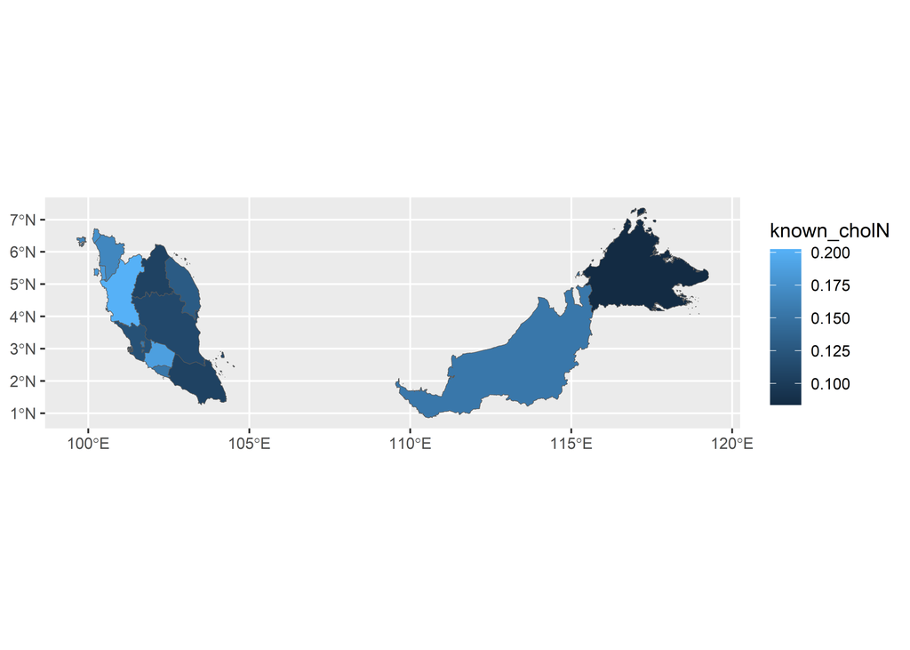

````markdown
```{r}
kcprev_state_mapds %>%
  ggplot(aes(fill = known_cholN)) +
  geom_sf()
```
````

6. we can also customised our plot - using esquisse addin

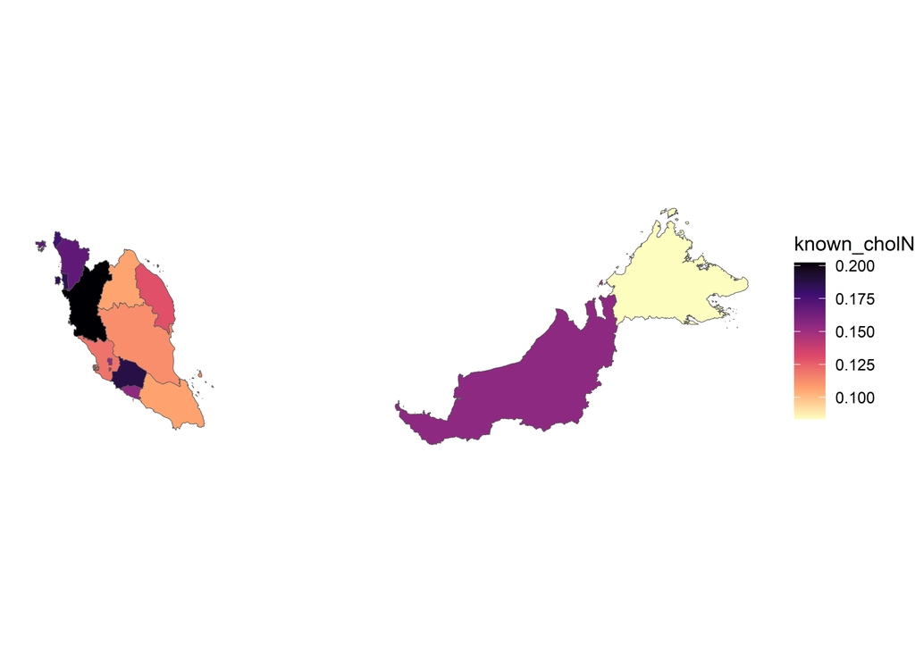

````markdown
```{r}
ggplot(kcprev_state_mapds) +
  aes(fill = known_cholN) +
  geom_sf(size = 1.2) +
  scale_fill_viridis_c(option = "magma", direction = -1) +
  theme_void()
```
````

# 5 Bonus: Plot Piramid Plot

## 5.1 DOSM Population (2023)

````markdown
```{r}
library(readxl)

DOSMPop23 <- read_excel("DOSMPopulation2023.xlsx") %>%
  mutate(Source = "DOSM23",
         across(.cols = where(is.character),
                .fns = ~ as.factor(.)),
         Gender = fct_recode(Gender,
                             "Male" = "Men",
                             "Female" = "Women"))

DOSMPop23
```
````

| AgeGroup | Gender | TotalPopulation | Source |
| --- | --- | --- | --- |
| >60 | Male | 1845000 | DOSM23 |
| 50 - 59 | Male | 1587200 | DOSM23 |
| 40 - 49 | Male | 2331100 | DOSM23 |
| 30 - 39 | Male | 3076900 | DOSM23 |
| 20 - 29 | Male | 3275200 | DOSM23 |
| 10 - 19 | Male | 2815000 | DOSM23 |
| 5 - 9 | Male | 1324200 | DOSM23 |
| >60 | Female | 1922500 | DOSM23 |
| 50 - 59 | Female | 1558800 | DOSM23 |
| 40 - 49 | Female | 2104700 | DOSM23 |

[output cut: 4 more lines]

## 5.2 NHMS 2019 Population

1. Import again our dataset

````markdown
```{r}
library(tidyverse)
library(haven)

nhms19ds <- read_sav("nhms19ds.sav") %>%
  as_factor()

nhms19ds %>%
  select(-c(indvid, hh_id)) %>%
  slice_sample(n = 30)
```
````

| state | strata_gp | A2101 | A2104 | A2104_grp | A2106_5grp | A2107 | A2108_3grp | A2109_4grp | A2221 | A2222_7grp | A2222_5grp | state_st | ebid | wtfinal_ncd | c01 | c02 | c03 | c03a | c04a | c04b | c04c | c04d | c05 | c06 | u303 | known_chol | undiagnosed_chol | total_chol | bodyweight1 | … |
| --- | --- | --- | --- | --- | --- | --- | --- | --- | --- | --- | --- | --- | --- | --- | --- | --- | --- | --- | --- | --- | --- | --- | --- | --- | --- | --- | --- | --- | --- | --- |
| Terengganu | Urban | Female | 34 | 30-34 | Malay | Malaysian Citizen | Married | Tertiary education | NA | Unpaid worker / Homemaker / Caregiver | Unpaid worker / Homemaker / Caregiver | 21 | 11030160024 | 1966.6813 | No | No | NA | NA | NA | NA | NA | NA | NA | NA | 3.2 | No | No | No | 58.7 | … |
| Pahang | Urban | Male | 48 | 45-49 | Malay | Malaysian Citizen | Widow(er)/Divercee | Tertiary education | Private employee | Private employee | Private employee | 11 | 06010340043 | 2112.4640 | Yes | No | NA | NA | NA | NA | NA | NA | NA | NA | 3.7 | No | No | No | 64.1 | … |
| Pahang | Rural | Female | 40 | 40-44 | Malay | Malaysian Citizen | Married | Primary education | Private employee | Private employee | Private employee | 12 | 06100320067 | 1166.6355 | No | No | NA | NA | NA | NA | NA | NA | NA | NA | 5.9 | No | Yes | Yes | 118.4 | … |
| Sabah | Rural | Male | 78 | 75 & above | Other Bumiputeras | Malaysian Citizen | Married | Primary education | Self-employed | Self employed | Self employed | 24 | 12070130012 | 844.4285 | No | No | NA | NA | NA | NA | NA | NA | NA | NA | 4.6 | No | No | No | 39.5 | … |
| Sarawak | Urban | Female | 67 | 65-69 | Chinese | Malaysian Citizen | Married | Primary education | NA | Not working (unemployed, health problem, old age & child) | NA | 25 | 13010030012 | 1685.6767 | Yes | No | NA | NA | NA | NA | NA | NA | NA | NA | 4.5 | No | No | No | 79.3 | … |
| Sarawak | Urban | Female | 58 | 55-59 | Others | Non-Malaysian Citizen | Married | Tertiary education | NA | Unpaid worker / Homemaker / Caregiver | Unpaid worker / Homemaker / Caregiver | 25 | 13010030075 | 200.0223 | Yes | Yes | Less than 1 year | NA | Yes | Yes | Yes | Yes | No | Private hospital | 6.2 | Yes | No | Yes | 62.4 | … |
| Sarawak | Rural | Female | 20 | 20-24 | Malay | Malaysian Citizen | Married | Primary education | NA | Unpaid worker / Homemaker / Caregiver | Unpaid worker / Homemaker / Caregiver | 26 | 13010050017 | 1833.3470 | No | No | NA | NA | NA | NA | NA | NA | NA | NA | 2.6 | No | No | No | 57 | … |
| N. Sembilan | Rural | Female | 66 | 65-69 | Chinese | Malaysian Citizen | Married | No formal education | NA | Not working (unemployed, health problem, old age & child) | NA | 10 | 05010010094 | 899.8102 | Yes | Yes | 1 year and more | 3 | Yes | Yes | Yes | Yes | No | Government clinic | 3.7 | Yes | No | Yes | 74.8 | … |
| Kedah | Rural | Female | 67 | 65-69 | Malay | Malaysian Citizen | Married | Secondary education | NA | Not working (unemployed, health problem, old age & child) | NA | 4 | 02100210049 | 838.4496 | Yes | No | NA | NA | NA | NA | NA | NA | NA | NA | NA | No | No | No | 57 | … |
| Kedah | Urban | Female | 24 | 20-24 | Malay | Malaysian Citizen | SIngle | Tertiary education | Self-employed | Self employed | Self employed | 3 | 02070470071 | 7828.7606 | No | No | NA | NA | NA | NA | NA | NA | NA | NA | 4.5 | No | No | No | 55.6 | … |

[output cut: 20 more lines]

2. Add new column, to count all available sample
- our data also dont have corresponding age group, so create age group

````markdown
```{r}
nhms19ds <- nhms19ds %>%
  mutate(nhmsall = 1, .before = everything()) %>%
  mutate(AgeGroup = cut(A2104,
                        breaks = c(9, 19, 29, 39, 49, 59, Inf),
                        labels = c("10 - 19",  "20 - 29", "30 - 39",
                                   "40 - 49",  "50 - 59", ">60")))

nhms19ds %>%
  select(-c(indvid, hh_id)) %>%
  slice_sample(n = 30)
```
````

| nhmsall | state | strata_gp | A2101 | A2104 | A2104_grp | A2106_5grp | A2107 | A2108_3grp | A2109_4grp | A2221 | A2222_7grp | A2222_5grp | state_st | ebid | wtfinal_ncd | c01 | c02 | c03 | c03a | c04a | c04b | c04c | c04d | c05 | c06 | u303 | known_chol | undiagnosed_chol | total_chol | … |
| --- | --- | --- | --- | --- | --- | --- | --- | --- | --- | --- | --- | --- | --- | --- | --- | --- | --- | --- | --- | --- | --- | --- | --- | --- | --- | --- | --- | --- | --- | --- |
| 1 | WP Labuan | Urban | Male | 25 | 25-29 | Malay | Malaysian Citizen | SIngle | Secondary education | Private employee | Private employee | Private employee | 28 | 15010020015 | 122.19900 | Yes | No | NA | NA | NA | NA | NA | NA | NA | NA | 3.6 | No | No | No | … |
| 1 | Kedah | Urban | Male | 37 | 35-39 | Malay | Malaysian Citizen | Married | Secondary education | Self-employed | Self employed | Self employed | 3 | 02060380047 | 4174.90600 | Yes | No | NA | NA | NA | NA | NA | NA | NA | NA | 5.1 | No | No | No | … |
| 1 | Sarawak | Urban | Male | 33 | 30-34 | Other Bumiputeras | Malaysian Citizen | Married | Tertiary education | Self-employed | Self employed | Self employed | 25 | 13120350026 | 4839.93537 | Yes | Yes | 1 year and more | 2 | No | Yes | Yes | Yes | Yes | Government clinic | NA | Yes | No | Yes | … |
| 1 | WP Labuan | Urban | Female | 62 | 60-64 | Malay | Malaysian Citizen | Married | Secondary education | NA | Retiree | Retiree | 28 | 15010020086 | 79.94060 | Yes | Yes | 1 year and more | 20 | Yes | Yes | Yes | Yes | No | Government clinic | 5.1 | Yes | No | Yes | … |
| 1 | N. Sembilan | Urban | Female | 42 | 40-44 | Indian | Malaysian Citizen | Married | Tertiary education | Private employee | Private employee | Private employee | 9 | 05050220079 | 1466.74060 | Yes | No | NA | NA | NA | NA | NA | NA | NA | NA | 4.9 | No | No | No | … |
| 1 | Sabah | Urban | Female | 20 | 20-24 | Malay | Malaysian Citizen | SIngle | Tertiary education | NA | Not working (unemployed, health problem, old age & child) | NA | 23 | 12010320011 | 957.13182 | Yes | No | NA | NA | NA | NA | NA | NA | NA | NA | 4.4 | No | No | No | … |
| 1 | WP Labuan | Urban | Male | 55 | 55-59 | Chinese | Malaysian Citizen | Married | Secondary education | NA | Not working (unemployed, health problem, old age & child) | NA | 28 | 15010020016 | 149.76424 | Yes | No | NA | NA | NA | NA | NA | NA | NA | NA | 3.9 | No | No | No | … |
| 1 | Perlis | Urban | Male | 51 | 50-54 | Malay | Malaysian Citizen | Married | Secondary education | Private employee | Private employee | Private employee | 17 | 09010030026 | 425.00500 | No | No | NA | NA | NA | NA | NA | NA | NA | NA | 6.1 | No | Yes | Yes | … |
| 1 | Selangor | Urban | Male | 33 | 30-34 | Others | Malaysian Citizen | Married | Primary education | Private employee | Private employee | Private employee | 19 | 10081200019 | 4441.20669 | No | No | NA | NA | NA | NA | NA | NA | NA | NA | 4.2 | No | No | No | … |
| 1 | Pahang | Rural | Female | 27 | 25-29 | Other Bumiputeras | Malaysian Citizen | Married | Primary education | NA | Unpaid worker / Homemaker / Caregiver | Unpaid worker / Homemaker / Caregiver | 12 | 06110470077 | 1449.84901 | No | No | NA | NA | NA | NA | NA | NA | NA | NA | 4.2 | No | No | No | … |

[output cut: 20 more lines]

3. Create survey design

````markdown
```{r}
nhms_alldsg <- svydesign(id = ~ebid,
                         strata = ~state_st,
                         weights = ~wtfinal_ncd,
                         data = nhms19ds,
                         nest = T)
```
````

4. Calculate our overall estimated population

````markdown
```{r}
NHMSPop19 <- svyby(~nhmsall,
                   by = ~A2101+AgeGroup,
                   design = nhms_alldsg,
                   FUN = svytotal,
                   na.rm = TRUE) %>%
  as_tibble() %>%
  select(-se) %>%
  mutate(nhmsall = as.integer(nhmsall),
         Source = "NHMS19",
         Source = as_factor(Source)) %>%
  rename("Gender" = "A2101",
         "TotalPopulation" = "nhmsall")
```
```{r}
NHMSPop19
```
````

| Gender | AgeGroup | TotalPopulation | Source |
| --- | --- | --- | --- |
| Male | 10 - 19 | 497920 | NHMS19 |
| Female | 10 - 19 | 402676 | NHMS19 |
| Male | 20 - 29 | 3081745 | NHMS19 |
| Female | 20 - 29 | 2786019 | NHMS19 |
| Male | 30 - 39 | 2633650 | NHMS19 |
| Female | 30 - 39 | 2397927 | NHMS19 |
| Male | 40 - 49 | 1789553 | NHMS19 |
| Female | 40 - 49 | 1705751 | NHMS19 |
| Male | 50 - 59 | 1431245 | NHMS19 |
| Female | 50 - 59 | 1442356 | NHMS19 |

[output cut: 2 more lines]

5. Combine Dataset
- since we want female on the left side, the female population need to be in negative form
- we also have to “sort” the age group

````markdown
```{r}
CombPop <- full_join(DOSMPop23, NHMSPop19) %>%
  mutate(TotalPopulation = case_when(Gender == "Female" ~ 0-TotalPopulation,
                                     Gender == "Male" ~ TotalPopulation),
         Gender = fct_relevel(Gender, "Female"),
         AgeGroup = fct_relevel(AgeGroup, "5 - 9",
                                "10 - 19",  "20 - 29", "30 - 39",
                                "40 - 49",  "50 - 59", ">60"))
```
```{r}
CombPop
```
````

| AgeGroup | Gender | TotalPopulation | Source |
| --- | --- | --- | --- |
| >60 | Male | 1845000 | DOSM23 |
| 50 - 59 | Male | 1587200 | DOSM23 |
| 40 - 49 | Male | 2331100 | DOSM23 |
| 30 - 39 | Male | 3076900 | DOSM23 |
| 20 - 29 | Male | 3275200 | DOSM23 |
| 10 - 19 | Male | 2815000 | DOSM23 |
| 5 - 9 | Male | 1324200 | DOSM23 |
| >60 | Female | -1922500 | DOSM23 |
| 50 - 59 | Female | -1558800 | DOSM23 |
| 40 - 49 | Female | -2104700 | DOSM23 |

[output cut: 16 more lines]

6. Plot Pyramid Plot with ggplot2

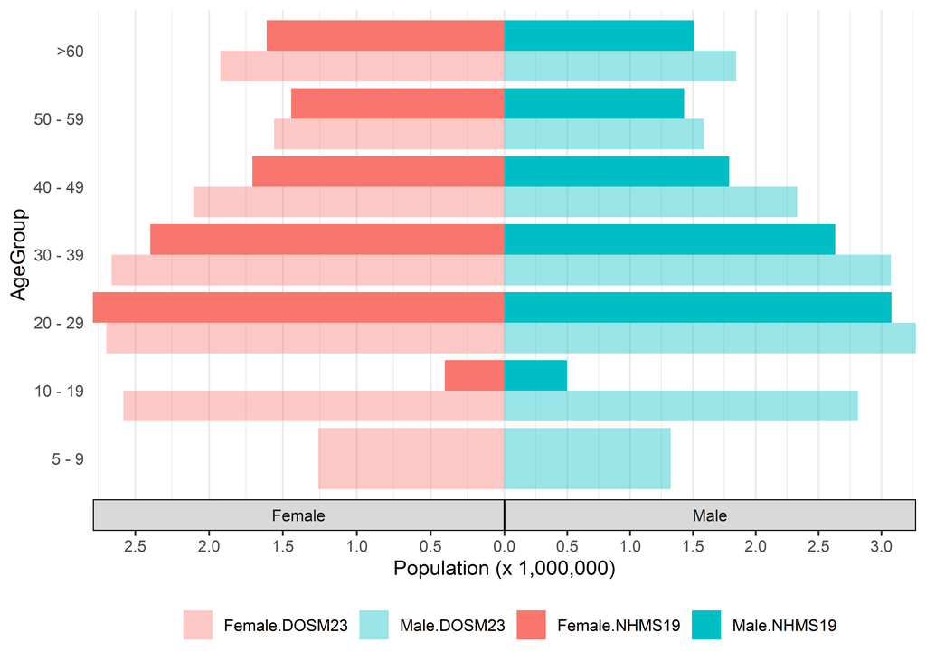

````markdown
```{r}
CombPop %>%
  ggplot(aes(x = AgeGroup, y = TotalPopulation, fill = interaction(Gender, Source))) +
  geom_col(position = "dodge") +
  scale_y_continuous(expand = c(0, 0), name = "Population (x 1,000,000)",
                     labels = function(x) scales::comma(abs(x / 1000000)),
                     breaks = seq(-4000000, 4000000, 500000)) +
  scale_fill_manual(values = hcl(h = c(15, 195, 15, 195),
                                 c = 100,
                                 l = 65,
                                 alpha = c(.4, .4, 1, 1)),
                    name = "") +
  coord_flip() +
  facet_wrap(. ~ Gender, scales = "free_x", strip.position = "bottom") +
  theme_bw() +
  theme(panel.border = element_blank(),
        axis.ticks.y = element_blank(),
        panel.grid.major.y = element_blank(),
        legend.position = "bottom",
        panel.spacing.x = unit(0, "pt"),
        strip.background = element_rect(colour = "black"))
```
````

# 6 Bonus: Age-standardised